# Spatial Transcriptomics Application

Sung

### Multiomics Overview

| 영역 | 기법/분석 | 설명 |
| --- | --- | --- |
| **면역학** | 5’ 면역 프로파일링 | 단일 세포 수준에서의 면역 반응을 분석하기 위한 기법 |
| **전체 전사체 프로파일링** | 3’ & 5’ 유전자 발현 | 전체 RNA의 발현을 세포 단위로 정밀하게 측정 |
| **단백체학** | 특징 바코딩, 세포 표면 단백질 발현 | 단일 세포 수준에서의 단백질 발현과 변이를 특정하기 위한 기법들 |
| **에피지네틱스** | Multiome (RNA-seq + ATAC-seq) | RNA 발현과 염색체 접근성을 동시에 측정하여 유전자 조절 메커니즘을 이해 |
| **기능적 유전체학** | 특징 바코딩, 단일 세포 CRISPR 스크리닝 | 유전자 기능을 연구하고 특정 유전자의 기능을 조절하는 실험 기법들 |
| **고정 및 FFPE 프로파일링** | Flex | 고정화된 샘플에서도 유전자 및 단백질 분석을 가능하게 하는 기술 |

| Area | Techniques/Analysis | Description |
| --- | --- | --- |
| **Immunology** | 5’ Immune Profiling | Techniques for analyzing immune responses at single-cell level |
| **Whole Transcriptome Profiling** | 3’ & 5’ Gene Expression | Precision measurement of RNA expression at a single-cell level |
| **Proteomics** | Feature Barcoding, Cell Surface Protein Expression | Techniques to specify protein expression and variants at single-cell level |
| **Epigenetics** | Multiome (RNA-seq + ATAC-seq) | Simultaneous measurement of RNA expression and chromatin accessibility to understand gene regulation mechanisms |
| **Functional Genomics** | Feature Barcoding, Single Cell CRISPR Screening | Techniques to study gene function and manipulate specific gene functions |
| **Fixed & FFPE Profiling** | Flex | Technologies enabling gene and protein analysis in fixed samples |

### Xenium in situ

Xenium in Situ

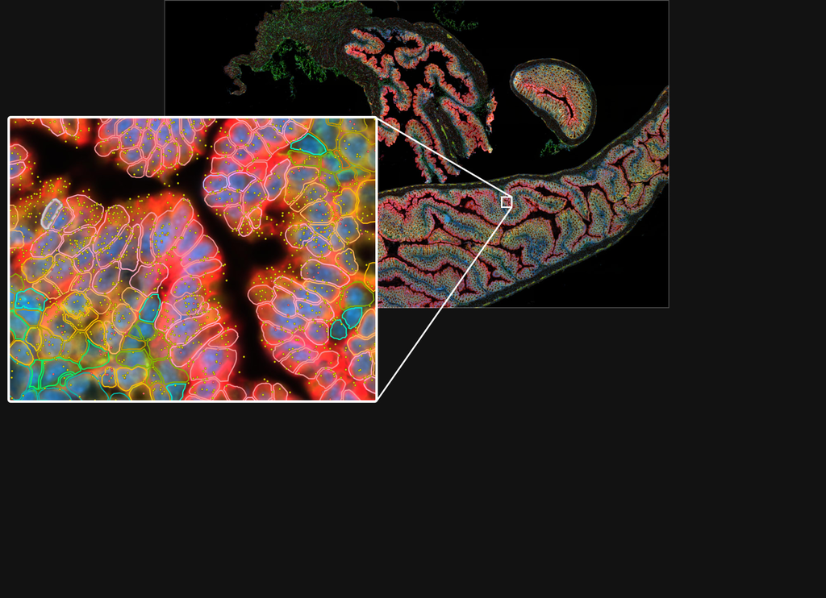

### Xenium Multimodal Cell Segmentation

Key components of this technology include:

- **Nucleus Segmentation**: This initial step involves detecting nuclei using DAPI images with a custom neural network trained on a variety of tissue types.
- **Cell Segmentation**: Following nucleus segmentation, the algorithm employs three methods to define cell boundaries. These include using cell boundary stains to identify true cell membrane boundaries, expanding from the nucleus to the cell interior stain edge, and a nuclear expansion method.
- **Multimodal Approach**: This involves the application of different staining methods to better define and differentiate cellular structures within the sample. The segmentation algorithm adjusts its approach based on the stain used, offering flexibility in handling diverse tissue preparations, including fresh frozen and FFPE samples.

The resources provided by 10X Genomics [link](https://cdn.10xgenomics.com/image/upload/v1710785020/CG000750_XeniumInSitu_CellSegmentation_TechNote_RevA.pdf)